# Sib pairs in UKBB

12/11/2018

Questions:

1. How many sib pairs are there
2. Is the distribution of sib pairs different from what we expect by chance? (e.g. due to ascertainment)

https://www.ncbi.nlm.nih.gov/pmc/articles/PMC3070763/

Helpfully, the data contains IBS0 (proportion of loci that are unshared between individuals) as well as IBS kinship (average sharing across all loci). Parent offspring will have 0% IBS0, and the IBS0 sharing between half sibs and fullsibs will follow different distributions, so there should be minimal overlap across these two dimensions.

## Analysis

Read in data

```r
library(data.table)
a <- fread("../data/ukb8786_rel_s488295.dat")
str(a)
```

```
## Classes 'data.table' and 'data.frame':   107162 obs. of  5 variables:
##  $ ID1    : int  1000074 1000082 1000082 1000153 1000244 1000269 1000292 1000332 1000332 1000422 ...
##  $ ID2    : int  2565994 1780150 4472051 5864791 3300733 5292668 3653129 2670354 4669830 1157810 ...
##  $ HetHet : num  0.046 0.044 0.046 0.044 0.076 0.051 0.046 0.058 0.062 0.076 ...
##  $ IBS0   : num  0.0145 0.0151 0.0133 0.0154 0.0043 0.01 0.0133 0.0029 0.0035 0.0039 ...
##  $ Kinship: num  0.06 0.0503 0.0729 0.0484 0.2536 ...
##  - attr(*, ".internal.selfref")=<externalptr>
```

```r
sum(a$Kinship == -1)
```

```
## [1] 36
```

Some of the relationships are -1, remove them

```r
a <- subset(a, Kinship != -1)
a$Kinship <- a$Kinship * 2
```

Distribution of all relationships

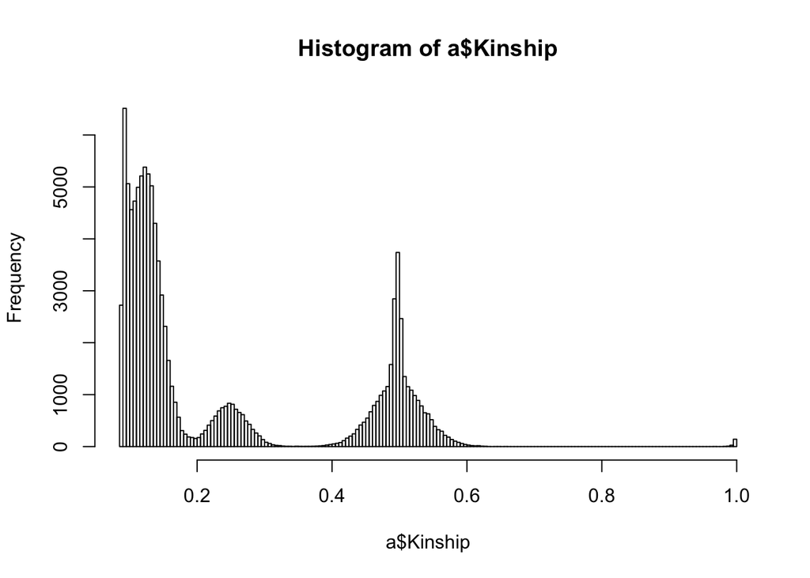

```r
hist(a$Kinship, breaks=200)
```

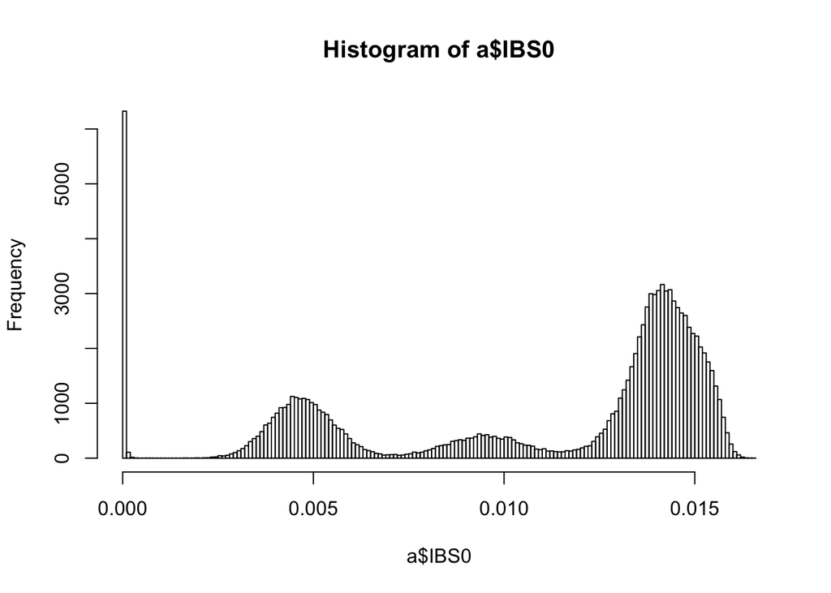

```r
hist(a$IBS0, breaks=200)
```

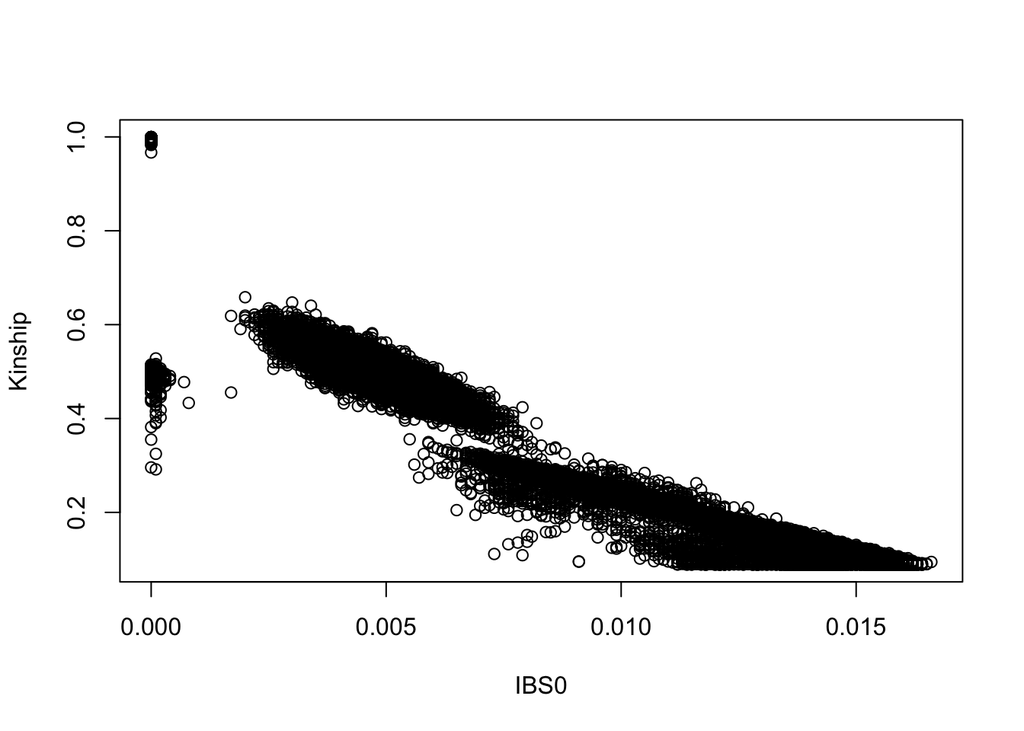

```r
plot(Kinship ~ IBS0, a)
```

Now we will try to identify the samples within the main central ovoid cluster, which should represent the sibling pairs.

Try k-means:

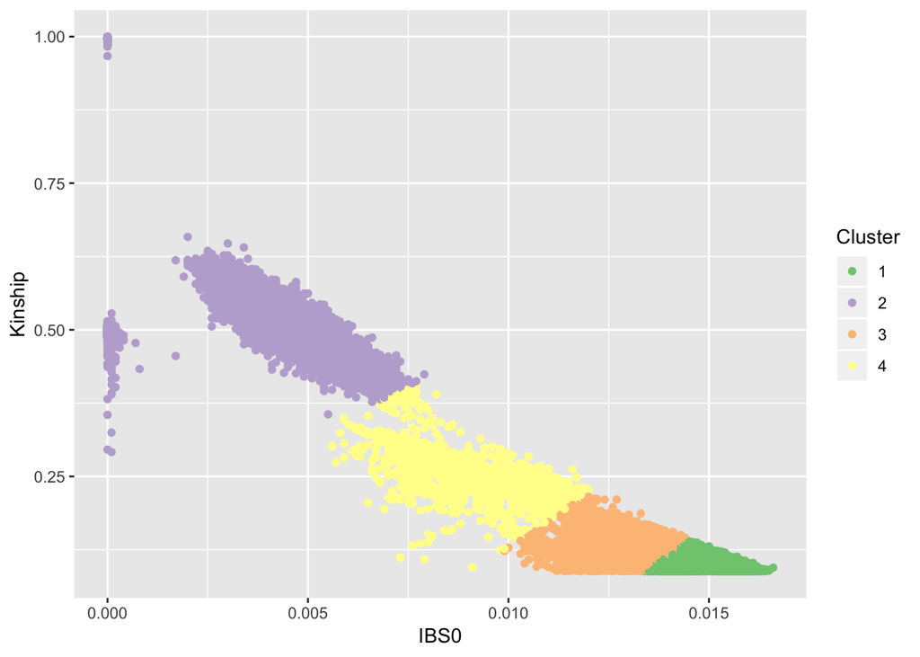

```r
temp <- cbind(scale(a$Kinship), scale(a$IBS0))

clust <- kmeans(temp, centers=4)
library(ggplot2)
ggplot(a, aes(x=IBS0, y=Kinship)) +
geom_point(aes(col=as.factor(clust$cluster))) +
scale_colour_brewer(type="qual") +
labs(colour="Cluster")
```

This does not work well.

Try gaussian mixture model:

```r
# library(ClusterR)
# gmm = GMM(temp, 4, dist_mode = "maha_dist", seed_mode = "random_subset", km_iter = 10, em_iter = 10, verbose = F)

library(mclust)
```

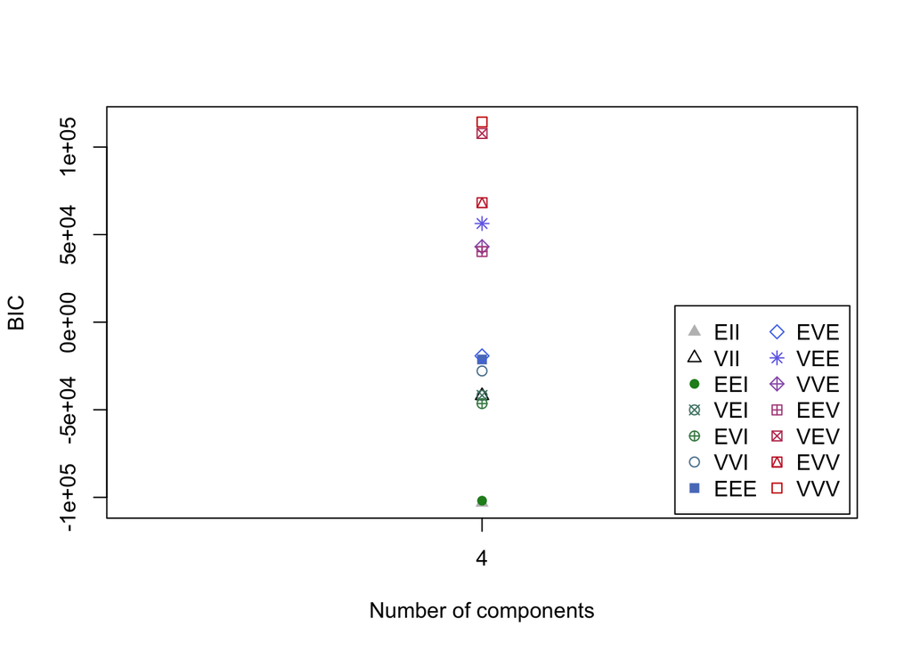

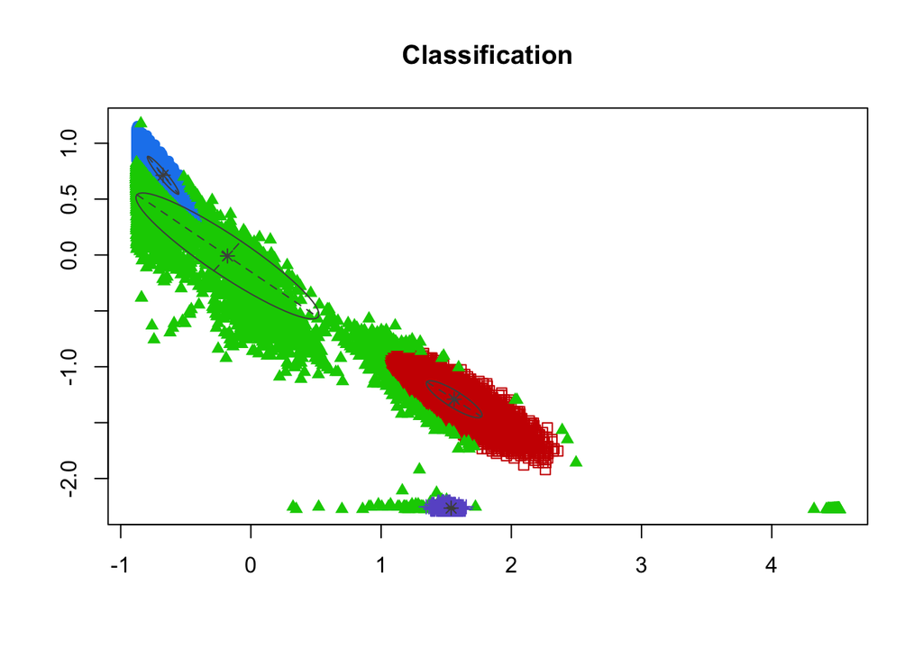

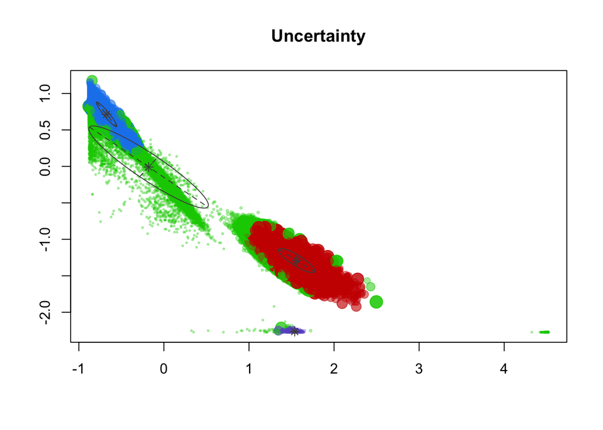

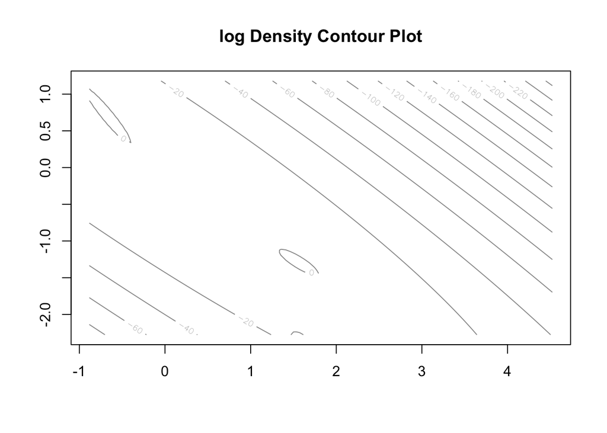

```r
temp <- cbind(scale(a$Kinship), scale(a$IBS0))
xyMclust <- Mclust(temp, G=4)
plot(xyMclust)
```

Better but still not good enough.

Try doing it by eye:

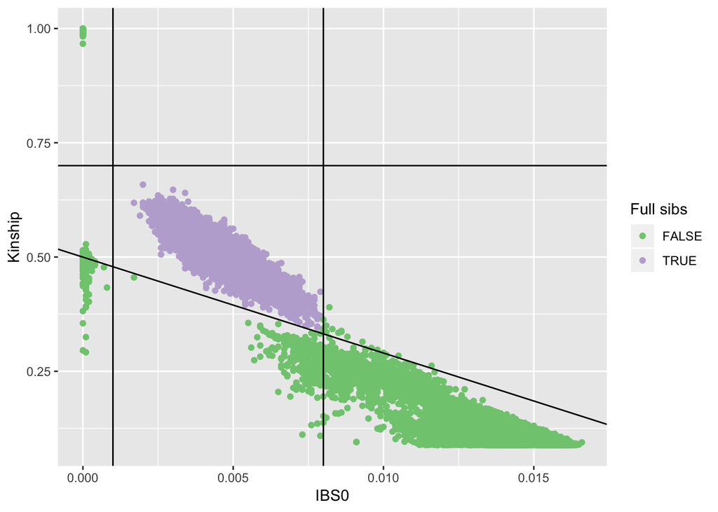

```r
library(ggplot2)
index <-    a$Kinship > (a$IBS0 * -21 + 0.5) &
            a$Kinship < 0.7 &
            a$IBS0 > 0.001 &
            a$IBS0 < 0.008
ggplot(a, aes(x=IBS0, y=Kinship)) +
geom_point(aes(col=as.factor(index))) +
scale_colour_brewer(type="qual") +
geom_abline(intercept=0.5, slope=-21) +
geom_hline(yintercept=0.7) +
geom_vline(xintercept=0.008) +
geom_vline(xintercept=0.001) +
labs(colour="Full sibs")
```

```r
sibs <- subset(a, index)
nrow(sibs)
```

```
## [1] 22658
```

Distribution of sibs

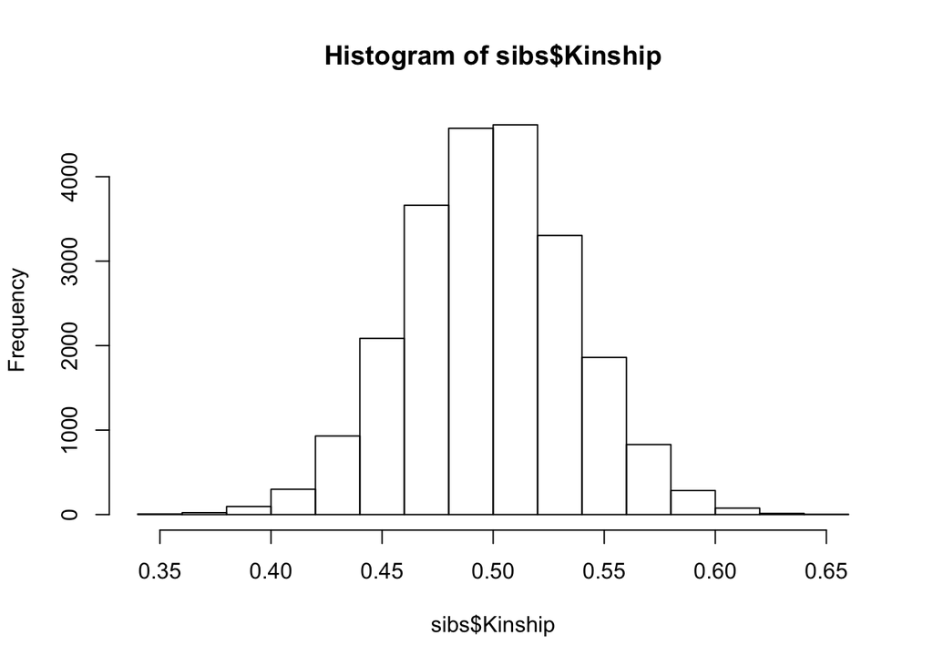

```r
hist(sibs$Kinship)
```

Summary of sibs

```r
summary(sibs$Kinship)
```

```
##    Min. 1st Qu.  Median    Mean 3rd Qu.    Max.
##  0.3458  0.4730  0.4988  0.4986  0.5238  0.6584
```

Save the sib pairs

```r
a$sibpair <- index
write.csv(a, file="../data/ukbb_sibs.csv")
```